# Supply Chain Management

## Project Overview

This project aims to perform a comprehensive analysis of a supply chain dataset to uncover key business insights and performance metrics across various operational dimensions. The dataset includes product information, sales performance, customer demographics, supplier data, manufacturing costs, transportation details, and quality control outcomes.

The objective of this analysis is to identify patterns, trends, and potential areas for optimization in the supply chain. Insights gained from this study will support data-driven decision-making in areas such as pricing strategy, inventory management, supplier evaluation, logistics planning, and quality assurance.

## Dataset Overview

The dataset includes the following key features:

- **Product Information:** Product type, SKU, price, availability, and stock levels.
- **Sales & Revenue:** Number of products sold and total revenue generated.
- **Customer Demographics:** Gender and identity segments contributing to sales.
- **Manufacturing Data:** Production volumes and associated manufacturing costs.
- **Logistics & Transportation:** Shipping carriers, transportation modes, routes, and transportation costs.
- **Supplier Details:** Supplier name and location.
- **Quality Control:** Inspection results and defect rates.

## Key Analytical Goals

- Measure sales and revenue performance by product type and customer demographics.
- Examine pricing effectiveness and its impact on product sales.
- Evaluate supplier contributions and manufacturing cost efficiency.
- Analyze transportation modes and routes in relation to shipping costs.
- Investigate quality metrics including inspection outcomes and defect rates.
- Compare performance metrics across different regional locations.

### Load Required libraries

```python
import numpy as np
import pandas as pd
import matplotlib.pyplot as plt
import seaborn as sns
```

### Load Data From CSV File

```python
# Load csv file
df = pd.read_csv("supply_chain_data.csv")
df.head(10)
```

|  | Product type | SKU | Price | Availability | Number of products sold | Revenue generated | Customer demographics | Stock levels | Lead times | Order quantities | ... | Location | Lead time | Production volumes | Manufacturing lead time | Manufacturing costs | Inspection results | Defect rates | Transportation modes | Routes | Costs |
| --- | --- | --- | --- | --- | --- | --- | --- | --- | --- | --- | --- | --- | --- | --- | --- | --- | --- | --- | --- | --- | --- |
| 0 | haircare | SKU0 | 69.808006 | 55 | 802 | 8661.996792 | Non-binary | 58 | 7 | 96 | ... | Mumbai | 29 | 215 | 29 | 46.279879 | Pending | 0.226410 | Road | Route B | 187.752075 |
| 1 | skincare | SKU1 | 14.843523 | 95 | 736 | 7460.900065 | Female | 53 | 30 | 37 | ... | Mumbai | 23 | 517 | 30 | 33.616769 | Pending | 4.854068 | Road | Route B | 503.065579 |
| 2 | haircare | SKU2 | 11.319683 | 34 | 8 | 9577.749626 | Unknown | 1 | 10 | 88 | ... | Mumbai | 12 | 971 | 27 | 30.688019 | Pending | 4.580593 | Air | Route C | 141.920282 |
| 3 | skincare | SKU3 | 61.163343 | 68 | 83 | 7766.836426 | Non-binary | 23 | 13 | 59 | ... | Kolkata | 24 | 937 | 18 | 35.624741 | Fail | 4.746649 | Rail | Route A | 254.776159 |
| 4 | skincare | SKU4 | 4.805496 | 26 | 871 | 2686.505152 | Non-binary | 5 | 3 | 56 | ... | Delhi | 5 | 414 | 3 | 92.065161 | Fail | 3.145580 | Air | Route A | 923.440632 |
| 5 | haircare | SKU5 | 1.699976 | 87 | 147 | 2828.348746 | Non-binary | 90 | 27 | 66 | ... | Bangalore | 10 | 104 | 17 | 56.766476 | Fail | 2.779194 | Road | Route A | 235.461237 |
| 6 | skincare | SKU6 | 4.078333 | 48 | 65 | 7823.476560 | Male | 11 | 15 | 58 | ... | Kolkata | 14 | 314 | 24 | 1.085069 | Pending | 1.000911 | Sea | Route A | 134.369097 |
| 7 | cosmetics | SKU7 | 42.958384 | 59 | 426 | 8496.103813 | Female | 93 | 17 | 11 | ... | Bangalore | 22 | 564 | 1 | 99.466109 | Fail | 0.398177 | Road | Route C | 802.056312 |
| 8 | cosmetics | SKU8 | 68.717597 | 78 | 150 | 7517.363211 | Female | 5 | 10 | 15 | ... | Mumbai | 13 | 769 | 8 | 11.423027 | Pending | 2.709863 | Sea | Route B | 505.557134 |
| 9 | skincare | SKU9 | 64.015733 | 35 | 980 | 4971.145988 | Unknown | 14 | 27 | 83 | ... | Chennai | 29 | 963 | 23 | 47.957602 | Pending | 3.844614 | Rail | Route B | 995.929461 |

10 rows × 24 columns

### Data Inspection

```python
# Get all columns name
df.columns
```

```
Index(['Product type', 'SKU', 'Price', 'Availability',
       'Number of products sold', 'Revenue generated', 'Customer demographics',
       'Stock levels', 'Lead times', 'Order quantities', 'Shipping times',
       'Shipping carriers', 'Shipping costs', 'Supplier name', 'Location',
       'Lead time', 'Production volumes', 'Manufacturing lead time',
       'Manufacturing costs', 'Inspection results', 'Defect rates',
       'Transportation modes', 'Routes', 'Costs'],
      dtype='object')
```

```python
#Drop un-usefull columns and update main data frame
df.drop(['Lead times','Lead time','Shipping times','Manufacturing lead time'],axis=1,inplace=True)
```

```python
# get dataframe infomations like data type, counts and non-null
df.info()
```

```
<class 'pandas.core.frame.DataFrame'>
RangeIndex: 100 entries, 0 to 99
Data columns (total 20 columns):
 #   Column                   Non-Null Count  Dtype
---  ------                   --------------  -----
 0   Product type             100 non-null    object
 1   SKU                      100 non-null    object
 2   Price                    100 non-null    float64
 3   Availability             100 non-null    int64
 4   Number of products sold  100 non-null    int64
 5   Revenue generated        100 non-null    float64
 6   Customer demographics    100 non-null    object
 7   Stock levels             100 non-null    int64
 8   Order quantities         100 non-null    int64
 9   Shipping carriers        100 non-null    object
 10  Shipping costs           100 non-null    float64
 11  Supplier name            100 non-null    object
 12  Location                 100 non-null    object
 13  Production volumes       100 non-null    int64
 14  Manufacturing costs      100 non-null    float64
 15  Inspection results       100 non-null    object
 16  Defect rates             100 non-null    float64
 17  Transportation modes     100 non-null    object
 18  Routes                   100 non-null    object
 19  Costs                    100 non-null    float64
dtypes: float64(6), int64(5), object(9)
memory usage: 15.8+ KB
```

```python
# Check null value in dataframe
df.isnull().sum()
```

```
Product type               0
SKU                        0
Price                      0
Availability               0
Number of products sold    0
Revenue generated          0
Customer demographics      0
Stock levels               0
Order quantities           0
Shipping carriers          0
Shipping costs             0
Supplier name              0
Location                   0
Production volumes         0
Manufacturing costs        0
Inspection results         0
Defect rates               0
Transportation modes       0
Routes                     0
Costs                      0
dtype: int64
```

```python
# get descriptive statistics of a dataframe like the central tendency, dispersion, and shape of a distribution
df.describe()
```

|  | Price | Availability | Number of products sold | Revenue generated | Stock levels | Order quantities | Shipping costs | Production volumes | Manufacturing costs | Defect rates | Costs |
| --- | --- | --- | --- | --- | --- | --- | --- | --- | --- | --- | --- |
| count | 100.000000 | 100.000000 | 100.000000 | 100.000000 | 100.000000 | 100.000000 | 100.000000 | 100.000000 | 100.000000 | 100.000000 | 100.000000 |
| mean | 49.462461 | 48.400000 | 460.990000 | 5776.048187 | 47.770000 | 49.220000 | 5.548149 | 567.840000 | 47.266693 | 2.277158 | 529.245782 |
| std | 31.168193 | 30.743317 | 303.780074 | 2732.841744 | 31.369372 | 26.784429 | 2.651376 | 263.046861 | 28.982841 | 1.461366 | 258.301696 |
| min | 1.699976 | 1.000000 | 8.000000 | 1061.618523 | 0.000000 | 1.000000 | 1.013487 | 104.000000 | 1.085069 | 0.018608 | 103.916248 |
| 25% | 19.597823 | 22.750000 | 184.250000 | 2812.847151 | 16.750000 | 26.000000 | 3.540248 | 352.000000 | 22.983299 | 1.009650 | 318.778455 |
| 50% | 51.239831 | 43.500000 | 392.500000 | 6006.352023 | 47.500000 | 52.000000 | 5.320534 | 568.500000 | 45.905622 | 2.141863 | 520.430444 |
| 75% | 77.198228 | 75.000000 | 704.250000 | 8253.976921 | 73.000000 | 71.250000 | 7.601695 | 797.000000 | 68.621026 | 3.563995 | 763.078231 |
| max | 99.171329 | 100.000000 | 996.000000 | 9866.465458 | 100.000000 | 96.000000 | 9.929816 | 985.000000 | 99.466109 | 4.939255 | 997.413450 |

# Exploratory Analysis

### Product Type Sales Performance

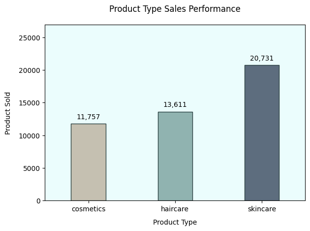

```python
# set chart style properties
plt.margins(0.3)

# Aggregate total Number of products sold by product type
sold = df.groupby('Product type')['Number of products sold'].sum().reset_index().sort_values(by='Number of products sold')

# create barplot
ax = sns.barplot(data = sold,
                 x = "Product type",
                 y = "Number of products sold",
                 palette = ['#c8c2ae','#8ab9b5','#586d83'],
                 hue = "Product type",
                 errorbar = None,
                 width = 0.4,
                 edgecolor="#2b4141")

# set barplot properties
ax.set_facecolor("#ebfdfd")
ax.set_title('Product Type Sales Performance',y=1.05)
ax.set_xlabel('Product Type',labelpad=10)
ax.set_ylabel('Product Sold',labelpad=10)

# set sales value on lagend
for container in ax.containers:
    ax.bar_label(container,
                 fmt='{:,.0f}',
                 padding=5)

plt.tight_layout()
plt.show()
```

The bar chart illustrates the total number of units sold for three product type: **cosmetics, haircare, and skincare**.

- **Skincare** products achieved the highest sales volume, with **20,731** units sold, indicating strong consumer demand in this category.
- **Haircare** followed with **13,611** units sold, showing moderate market performance.
- **Cosmetics** registered the lowest sales among the three, with **11,757** units sold.

This data highlights a clear consumer preference for skincare products, significantly outperforming both haircare and cosmetics. The insights suggest potential for increased investment or marketing focus on the skincare category to further leverage its market traction. and For both Haircare and Cosmetics, a dual approach of strategic niche identification and aggressive, targeted promotions is crucial for revenue growth.

### Revenue Contribution by Product Type

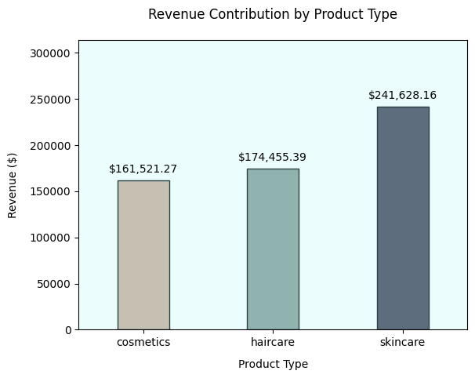

```python
# set chart style properties
plt.margins(0.3)

# Aggregate total Revenue generated by product type
revenue = df.groupby('Product type')['Revenue generated'].sum().reset_index().sort_values(by='Revenue generated')

# create barplot
ax = sns.barplot(data = revenue,
                 x = "Product type",
                 y = "Revenue generated",
                 palette = ['#c8c2ae','#8ab9b5','#586d83'],
                 hue = "Product type",
                 errorbar = None,
                 width = 0.4,
                 edgecolor="#2b4141")

# set barplot properties
ax.set_facecolor("#ebfdfd")
ax.set_title('Revenue Contribution by Product Type',y=1.05)
ax.set_xlabel('Product Type',labelpad=10)
ax.set_ylabel('Revenue ($)',labelpad=10)

# set cost value on lagend
for container in ax.containers:
    ax.bar_label(container,
                 fmt='${:,.2f}',
                 padding=5)

plt.show()
```

The bar chart presents a clear picture of revenue distribution across three key product types: **cosmetics, haircare, and skincare**.

- **Skincare** products stand out, generating the highest revenue at **$241,628.16** , which indicates robust consumer interest.
- **Haircare** products secured the second spot with **$174,455.39**, reflecting a solid market presence.
- **Cosmetics** recorded the lowest revenue at **$161,521.27**.

We've observed that skincare product sales and their corresponding revenue are dominant, surpassing both haircare and cosmetic categories. The insights suggest potential for increased investment or marketing focus on the skincare category to further leverage its market traction. and For both Haircare and Cosmetics, a dual approach of strategic niche identification and aggressive, targeted promotions is crucial for revenue growth.

### Revenue Breakdown by Customer Demographics and Product Type

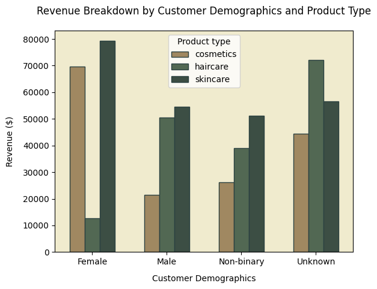

```python
# Aggregate total Revenue generated by Customer demographics and product type
revenue = df.groupby(['Customer demographics','Product type'])['Revenue generated'].sum().reset_index()

# create barplot
ax = sns.barplot(data = revenue,
                 x = "Customer demographics",
                 y = "Revenue generated",
                 palette = ['#AA8B56','#4E6C50','#395144'],
                 hue = "Product type",
                 errorbar = None,
                 width = 0.6,
                 edgecolor="#2b4141")

# set barplot properties
ax.set_facecolor("#F0EBCE")
ax.set_title('Revenue Breakdown by Customer Demographics and Product Type',y=1.05)
ax.set_xlabel('Customer Demographics',labelpad=10)
ax.set_ylabel('Revenue ($)',labelpad=10)

plt.tight_layout()
plt.show()
```

This clustered bar chart breaks down revenue by customer demographics (Female, Male, Non-binary, Unknown) across three product types: **Cosmetics, Haircare, and Skincare**.

### Relationship Between Price And Number Of Product Sold

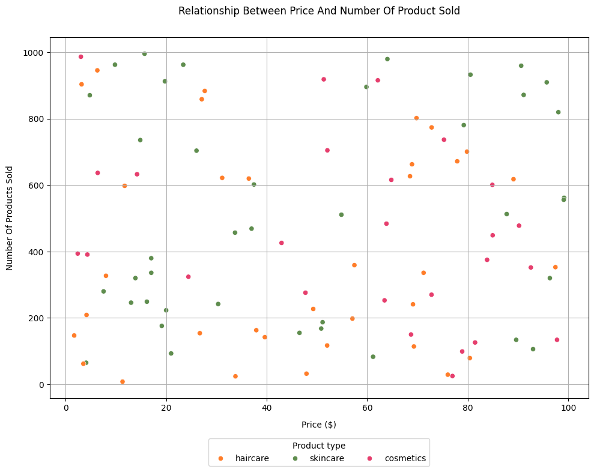

```
The correlation between Price and number of product sold is: 0.0057
```

```python
# set chart style properties
plt.figure(figsize=(10, 8))

# create scatterplot
ax = sns.scatterplot(data=df,
                     x='Price',
                     y='Number of products sold',
                     hue='Product type',
                     palette=['#FF7D29','#5F8D4E','#E63E6D'],)

# move scatterplot lagend to center bottom
sns.move_legend(ax,
                "lower center",
                bbox_to_anchor=(0.5, -0.20),
                ncol=3,
                title='Product type',
                frameon=True,
)

# set scatterplot properties
ax.set_title('Relationship Between Price And Number Of Product Sold',y=1.05)
ax.set_ylabel('Number Of Products Sold',labelpad=10)
ax.set_xlabel('Price ($)',labelpad=10)

plt.grid(True)
plt.tight_layout()
plt.show()

print(f"The correlation between Price and number of product sold is: {df['Price'].corr(df['Number of products sold']):.4f}")
```

This scatter plots chart shows the relationship between price and the number of products sold across three product types: **Cosmetics, Haircare, and Skincare**.

The absence of a clear, strong correlation between price and the number of products sold for any of the three product types indicates that price alone is not the primary determinant of sales volume.

### Manufacturing Cost Breakdown by Supplier and Product

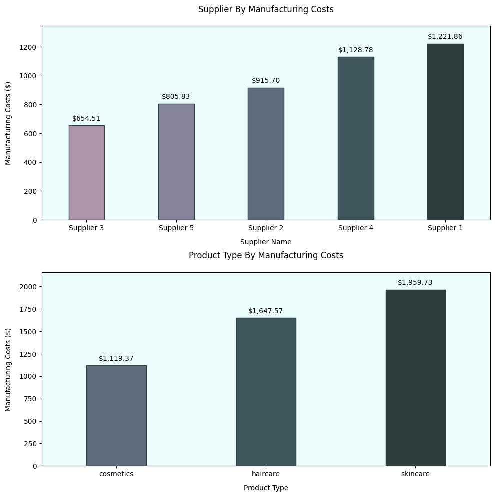

```python
# set chart style properties
plt.figure(figsize = (10,10))

# set chart grid properties
plt.subplot(2,1,1)

# set chart style properties
plt.margins(0.1)

# Aggregate total Manufacturing costs by Supplier name
manufacturing_cost_supplier = df.groupby('Supplier name')['Manufacturing costs'].sum().reset_index().sort_values(by="Manufacturing costs")

# create barplot
ax = sns.barplot(manufacturing_cost_supplier,
                 x = 'Supplier name',
                 y = 'Manufacturing costs',
                 palette = ['#b392b1','#82809f','#586d83','#3b5862','#2b4141'],
                 hue = "Supplier name",
                 errorbar = None,
                 width = 0.4,
                 edgecolor="#2b4141")

# set barplot properties
ax.set_facecolor("#ebfdfd")
ax.set_title('Supplier By Manufacturing Costs',y=1.05)
ax.set_xlabel('Supplier Name',labelpad=10)
ax.set_ylabel('Manufacturing Costs ($)',labelpad=10)

# set cost value on lagend
for container in ax.containers:
    ax.bar_label(container,
                 fmt='${:,.2f}',
                 padding=5)

# set chart grid properties
plt.subplot(2,1,2)

# set chart style properties
plt.subplots_adjust(hspace=0.4)
plt.margins(0.1)

# Aggregate total Manufacturing costs by Product type
manufacturing_cost_product = df.groupby('Product type')['Manufacturing costs'].sum().reset_index().sort_values(by="Manufacturing costs")

# create barplot
ax = sns.barplot(manufacturing_cost_product,
                 x = 'Product type',
                 y = 'Manufacturing costs',
                 palette = ['#586d83','#3b5862','#2b4141'],
                 hue = "Product type",
                 errorbar = None,
                 width = 0.4,
                 edgecolor="#2b4141")

# set barplot properties
ax.set_facecolor("#ebfdfd")
ax.set_title('Product Type By Manufacturing Costs',y=1.05)
ax.set_xlabel('Product Type',labelpad=10)
ax.set_ylabel('Manufacturing Costs ($)',labelpad=10)

# set cost value on lagend
for container in ax.containers:
    ax.bar_label(container,
                 fmt='${:,.2f}',
                 padding=5)

plt.tight_layout()
plt.show()
```

Consider shifting more production to Supplier 3 if quality and capacity meet requirements. and negotiation with Supplier 1 and 4 to reduce cost

- **Skincare** has the highest manufacturing cost: **$1,959.73**
- **Haircare** follows: **$1,647.57**
- **Cosmetics** are the least costly to produce: **$1,119.37**

Skincare and haircare products require significantly higher investment. Consider pricing strategies to ensure profit margins.Investigate if high manufacturing cost in skincare is justified by revenue or perceived value.

### Price Vs Manufacturing Cost

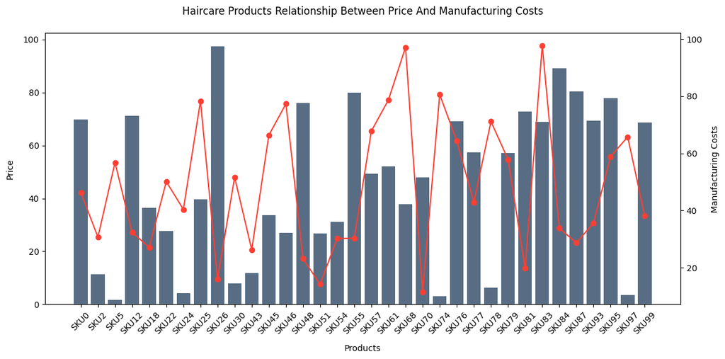

```python
# get all data, where Product type is haircare
product = df[df['Product type'] == "haircare"]

# set chart style properties
fig, ax1 = plt.subplots(figsize=(12, 6))

# twinx for second y axis on same chart
ax2 = ax1.twinx()

# create barplot
ax1.bar(product['SKU'], product['Price'],color="#586d83")

# plot second chart
ax2.plot(product['SKU'], product['Manufacturing costs'], 'o-', color="#FF3F33" )

# set chart properties
ax1.set_xlabel('Products',labelpad=10)
ax1.tick_params(axis='x', labelbottom=True,rotation=45)
ax1.set_ylabel('Price',labelpad=10)
ax2.set_ylabel('Manufacturing Costs',labelpad=10)

plt.title('Haircare Products Relationship Between Price And Manufacturing Costs',y=1.05)
fig.tight_layout(h_pad=10)
plt.show()
```

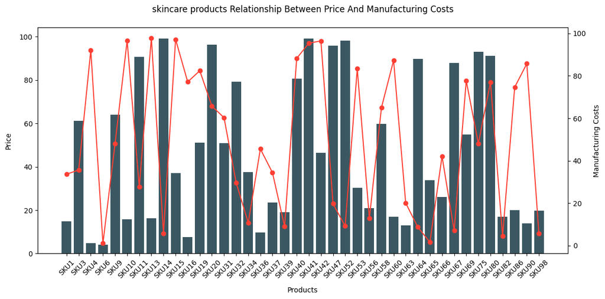

```python
# get all data, where Product type is skincare
product = df[df['Product type'] == "skincare"]

# set chart style properties
fig, ax1 = plt.subplots(figsize=(12, 6))

# twinx for second y axis on same chart
ax2 = ax1.twinx()

# create barplot
ax1.bar(product['SKU'], product['Price'],color="#3b5862")

# plot second chart
ax2.plot(product['SKU'], product['Manufacturing costs'], 'o-', color="#FF3F33" )

# set chart properties
ax1.set_xlabel('Products',labelpad=10)
ax1.tick_params(axis='x', labelbottom=True,rotation=45)
ax1.set_ylabel('Price',labelpad=10)
ax2.set_ylabel('Manufacturing Costs',labelpad=10)

plt.title('skincare products Relationship Between Price And Manufacturing Costs',y=1.05)
fig.tight_layout(h_pad=10)
plt.show()
```

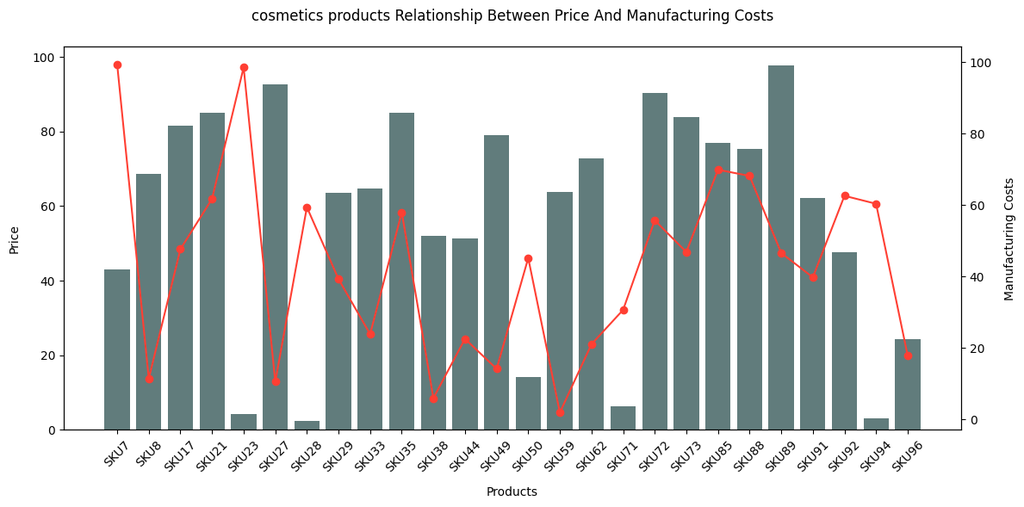

```python
# get all data, where Product type is skincare
product = df[df['Product type'] == "cosmetics"]

# set chart style properties
fig, ax1 = plt.subplots(figsize=(12, 6))

# twinx for second y axis on same chart
ax2 = ax1.twinx()

# create barplot
ax1.bar(product['SKU'], product['Price'],color="#617c7c")

# plot second chart
ax2.plot(product['SKU'], product['Manufacturing costs'], 'o-', color="#FF3F33" )

# set chart properties
ax1.set_xlabel('Products',labelpad=10)
ax1.tick_params(axis='x', labelbottom=True,rotation=45)
ax1.set_ylabel('Price',labelpad=10)
ax2.set_ylabel('Manufacturing Costs',labelpad=10)

plt.title('cosmetics products Relationship Between Price And Manufacturing Costs',y=1.05)
fig.tight_layout(h_pad=10)
plt.show()
```

[figure not shown]

```python
# create lmplot
ax = sns.lmplot(df,
                x="Manufacturing costs",
                y="Price",
                hue="Product type",
                col="Product type",
                palette = ['#AA8B56','#3b5862','#427D9D'])

fig = ax.fig
fig.suptitle('Products Relationship Between Price And Manufacturing Costs', fontsize=16,y=1.05)

plt.tight_layout()
plt.show()
```

This charts displays the relationship between price and manufacturing costs across three product types: **Cosmetics, Haircare, and Skincare**.

- There is a large disparity between price and cost.
- There's no immediately obvious strong positive or negative correlation between price and manufacturing costs across all SKUs.
- Some low-priced items have high costs, and vice versa.

Consider a review of SKUs with high cost but low price – potential margin loss. Optimize pricing or reduce manufacturing cost on underperforming SKUs. improve pricing strategy

### Manufacturing Cost vs Revenue

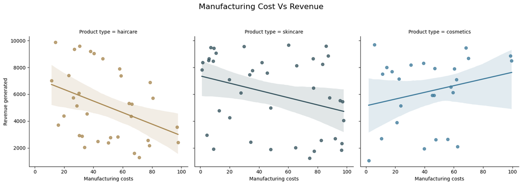

```python
# create lmplot
ax = sns.lmplot(df,
                x="Manufacturing costs",
                y="Revenue generated",
                hue="Product type",
                col="Product type",
                palette = ['#AA8B56','#3b5862','#427D9D'])

fig = ax.fig
fig.suptitle('Manufacturing Cost Vs Revenue', fontsize=16,y=1.05)

plt.tight_layout()
plt.show()
```

This scatter plots chart shows the relationship between manufacturing costs and revenue generated across three product types: **Cosmetics, Haircare, and Skincare**.

- **Haircare:** There appears to be a moderate to strong negative correlation between manufacturing costs and revenue generated. As manufacturing costs increase, the revenue generated tends to decrease.
- **Skincare:** There appears to be a weak to moderate negative correlation between manufacturing costs and revenue generated. it's not as steep as haircare, and there's more scatter in the data points.
- **Cosmetics:** There appears to be a weak to moderate positive correlation between manufacturing costs and revenue generated. This indicates that for cosmetics, products with higher manufacturing costs tend to generate higher revenue, although the relationship isn't very strong.

For haircare and skincare, the data strongly suggests a need to critically evaluate high-cost products. Are their high manufacturing costs justified by market performance. while Cosmetics is more aligned with the idea that investing in product quality can lead to slightly better market performance.

### Shipping Carrier By Shipping Cost

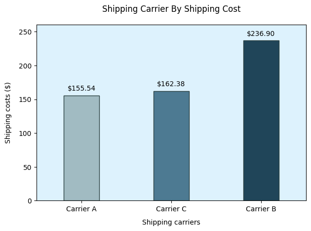

```python
# Aggregate total Shipping costs by Shipping carriers
shipping_cost = df.groupby('Shipping carriers')['Shipping costs'].sum().reset_index().sort_values(by="Shipping costs")

# set chart style properties
plt.margins(0.1)

# create barplot
ax = sns.barplot(shipping_cost,
                 x = 'Shipping carriers',
                 y = 'Shipping costs',
                 palette = ['#9BBEC8','#427D9D','#164863'],
                 hue = "Shipping carriers",
                 errorbar = None,
                 width = 0.4,
                 edgecolor="#2b4141")

# set barplot properties
ax.set_facecolor("#DDF2FD")
ax.set_title('Shipping Carrier By Shipping Cost',y=1.05)
ax.set_xlabel('Shipping carriers',labelpad=10)
ax.set_ylabel('Shipping costs ($)',labelpad=10)

# set sales value on lagend
for container in ax.containers:
    ax.bar_label(container,
                 fmt='${:,.2f}',
                 padding=5)

plt.tight_layout()
plt.show()
```

Based solely on shipping cost, **Carrier A is the most cost-effective option**, followed closely by Carrier C. Carrier B is considerably more expensive than the other two.

The insights suggest Prioritize Carrier A for Cost Savings and use Carrier C as secondry option. Investigate the Discrepancy with Carrier B

### Modes Of Transportation

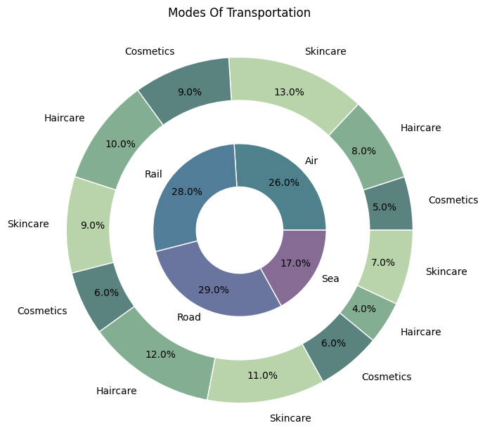

```python
# Aggregate value counts of Transportation modes by product type
transportation = df.groupby(['Transportation modes','Product type'])['Transportation modes'].value_counts().reset_index()

# set chart style properties
fig, ax = plt.subplots(figsize=(7, 7))

# Outer pie chart data
wedges_outer, texts_outer, autotexts_outer = ax.pie(transportation['count'],
                                                    radius=1.2,
                                                    labels=transportation['Product type'].str.title(),
                                                    autopct='%1.1f%%',
                                                    pctdistance=0.85,
                                                    colors=['#5A827E','#84AE92','#B9D4AA'],
                                                    wedgeprops=dict(width=0.3, edgecolor='w'))

# Inner pie chart data
wedges_inner, texts_inner, autotexts_inner = ax.pie(transportation.groupby(['Transportation modes'])['count'].sum(),
                                                    radius=0.6,
                                                    labels=transportation['Transportation modes'].unique(),
                                                    autopct='%1.1f%%',
                                                    pctdistance=0.75,
                                                    colors=['#4e818c','#527d99','#69759e','#866b95'],
                                                    wedgeprops=dict(width=0.3, edgecolor='w'))

plt.title('Modes Of Transportation', y=1.05)
plt.axis('equal')
plt.show()
```

This is a donut chart that illustrates the breakdown of transportation modes for three product types: **Cosmetics, Haircare, and Skincare**. The inner ring shows the overall distribution of major transportation modes, while the outer ring provides a more granular view, showing the percentage contribution of each product type within each mode of transport

**Overall Modes of Transportation**

- **Road:** Accounts for the largest share at **29.0%**.
- **Rail:** Is a close second at **28.0%**.
- **Air:** Represents **26.0%**.
- **Sea:** Is the smallest portion at **17.0%**.

This shows land-based transport Road and Rail is dominant, followed closely by air, with sea transport being the least utilized.

### Transportation Costs Relationship With Mode And Location

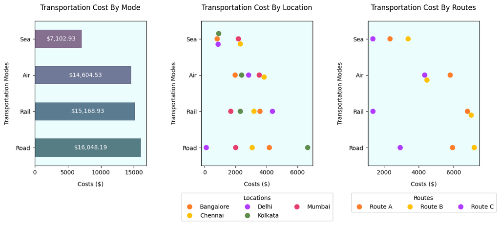

```python
# set chart style properties
plt.figure(figsize=(12,6))

# set chart grid properties
plt.subplot(1,3,1)

# Aggregate total costs sold by Transportation modes
mode_cost = df.groupby(['Transportation modes'])['Costs'].sum().reset_index().sort_values(by="Costs")

# create barplot
ax = sns.barplot(mode_cost,
            x='Costs',
            y='Transportation modes',
            hue='Transportation modes',
            palette=['#866b95','#69759e','#527d99','#4e818c'],
            width=.5
           )

# set cost value on lagend
for container in ax.containers:
    ax.bar_label(container,
                 fmt='${:,.2f}',
                 padding=5,
                 label_type="center",
                 color='white')

# set barplot properties
ax.set_facecolor("#ebfdfd")
ax.set_title('Transportation Cost By Mode',y=1.05)
ax.set_ylabel('Transportation Modes',labelpad=10)
ax.set_xlabel('Costs ($)',labelpad=10)

# set chart grid properties
plt.subplot(1,3,2)

# Aggregate total costs sold by Transportation modes and location
cost = df.groupby(['Transportation modes','Location'])['Costs'].sum().reset_index()

# create swarmplot
ax = sns.swarmplot(data=cost,
                   x="Costs",
                   y="Transportation modes",
                   hue="Location",
                   size=9,
                   palette=['#FF7D29','#FFC107','#B13BFF','#5F8D4E','#E63E6D'],
                   order=mode_cost['Transportation modes'])

# move scatterplot lagend to center bottom
sns.move_legend(ax,
                "lower center",
                bbox_to_anchor=(0.5, -0.40,),
                ncol=3,
                title='Locations',
                frameon=True,
)

# set swarmplot properties
ax.set_facecolor("#ebfdfd")
ax.set_title('Transportation Cost By Location',y=1.05)
ax.set_ylabel('Transportation Modes',labelpad=10)
ax.set_xlabel('Costs ($)',labelpad=10)

# set chart grid properties
plt.subplot(1,3,3)

# Aggregate total costs sold by Transportation modes and routes
cost = df.groupby(['Transportation modes','Routes'])['Costs'].sum().reset_index()

# create swarmplot
ax = sns.swarmplot(data=cost,
                   x="Costs",
                   y="Transportation modes",
                   hue="Routes",
                   size=9,
                   palette=['#FF7D29','#FFC107','#B13BFF'],
                   order=mode_cost['Transportation modes'])

# move scatterplot lagend to center bottom
sns.move_legend(
    ax, "lower center",
    bbox_to_anchor=(0.5, -0.34),
    ncol=3,
    title='Routes',
    frameon=True,
)

# set swarmplot properties
ax.set_facecolor("#ebfdfd")
ax.set_title('Transportation Cost By Routes',y=1.05)
ax.set_ylabel('Transportation Modes',labelpad=10)
ax.set_xlabel('Costs ($)',labelpad=10)

plt.tight_layout()
plt.show()
```

**1. Transportation Cost By Mode:**

- **Road** transport incurs the highest cost **$16,048.19**, followed closely by **Rail $15,168.93**, then **Air $14,604.53**, and **Sea** is the least expensive mode **7,102.93**.

**2. Transportation Cost By Location:** This plot shows transportation costs by mode for five different locations **Bangalore, Chennai, Delhi, Kolkata, Mumbai**.

**3. Transportation Cost By Routes:** This plot shows transportation costs by mode for three different routes **Route A, Route B, Route C**.

Prioritize Sea transport where feasible to minimize costs.

### Inspection Results

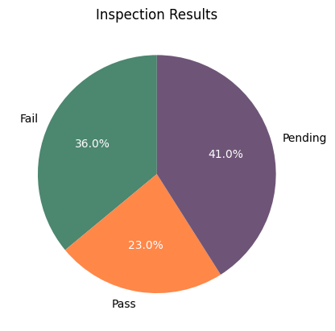

```python
# Aggregate value counts of Inspection results
inspection_results = df.groupby(['Inspection results'])['Inspection results'].value_counts().reset_index()

# create pie chart
wedges, texts, autotexts = plt.pie(inspection_results['count'],
                                   labels=inspection_results['Inspection results'],
                                   autopct='%1.1f%%',
                                   startangle=90,
                                   colors=['#4c8770','#ff8748','#6e5577'])

# set pie chart properties
for autotext in autotexts:
    autotext.set_color('white')

plt.title('Inspection Results')
plt.show()
```

This pie chart displays the distribution of inspection results for products. It categorizes results into **Pending, Fail, and Pass,** showing the percentage each category represents out of the total.

- **Pending:** The largest slice, accounting for **41.0%** of all inspection results. This means nearly half of the inspections are still awaiting a final outcome.
- **Fail:** A significant portion, representing **36.0%** of the results. This indicates that more than one-third of the products inspected did not meet quality standards.
- **Pass:** The smallest slice, at **23.0%**. This means less than a quarter of the products inspected successfully passed.

The inspection results present a critical concern regarding product quality and the efficiency of the inspection process.Prioritize a thorough investigation into the reasons for the high failure rate and reduce the pending rate to get faster feedback on product quality.

### Defect Rates By Supplier And Product Type

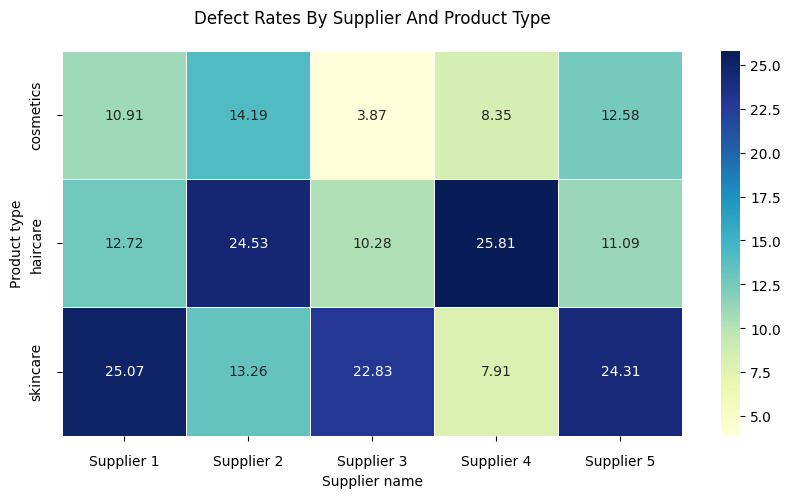

```python
# # Aggregate total Defect rates by Supplier name and Product type
defect_rate = df.groupby(['Supplier name','Product type'])['Defect rates'].sum().reset_index()

# set chart style properties
plt.figure(figsize=(10, 5))

# create heatmap
ax = sns.heatmap(defect_rate.pivot(index = 'Product type',
                            columns = 'Supplier name',
                            values = 'Defect rates'),
                            annot=True,
                            cmap="YlGnBu",
                            fmt=".2f",
                            linewidths=.5,)

plt.title('Defect Rates By Supplier And Product Type', y=1.05)
ax.tick_params(axis='both',pad=10)
plt.show()
```

This heatmap displays the defect rates three product types **Cosmetics, Haircare, and Skincare** across various suppliers **Supplier 1, Supplier 2, Supplier 3, Supplier 4, Supplier 5**. The color intensity indicates the magnitude of the defect rate, with darker blue representing higher defect rates and lighter yellow representing lower defect rates. The exact defect rate is also displayed as a numerical value within each cell.

Defect rates vary significantly across suppliers and product types. There isn't one single best or worst supplier across all product categories.

- **Supplier 3** consistently delivers low defect rates for both **Cosmetics and Haircare**.
- **Supplier 4** is excellent for Skincare but performs poorly for **Haircare**.
- **Supplier 1, 2, and 5** show fluctuating performance, often having high defect rates for at least one product type. **Supplier 1 and 5** are particularly problematic for **Skincare**.

The defect rate data clearly shows that supplier performance is highly dependent on the specific product type. There is no single supplier that consistently offers the lowest defect rates across all product categories. This necessitates a diversified and strategic approach to supplier management.

### Relationship Between Manufacturing Costs and Defect Rates

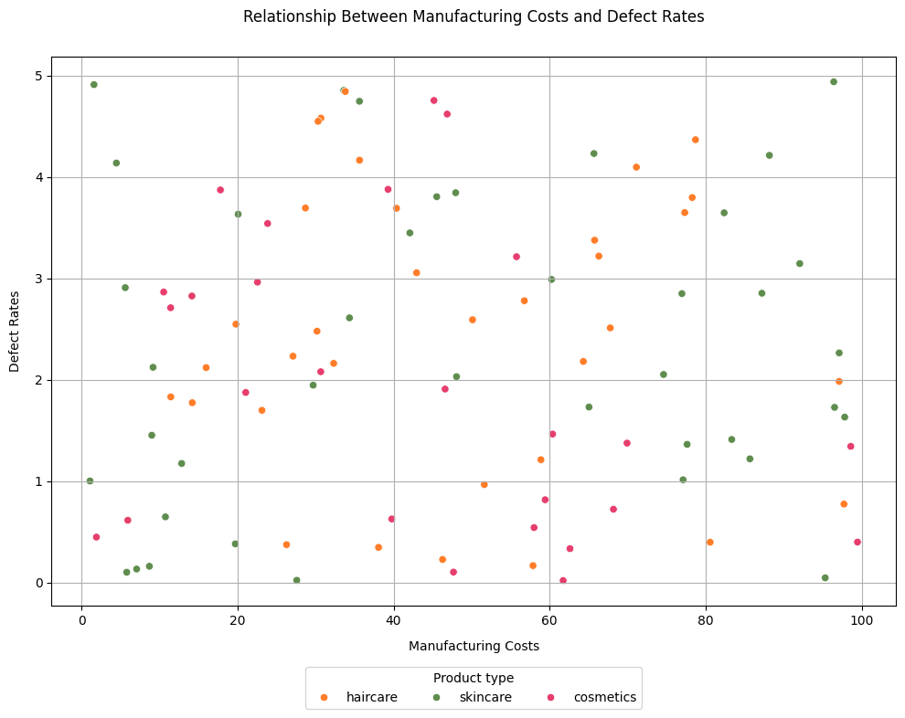

[output not shown]

```python
# set chart style properties
plt.figure(figsize=(10, 8))

# create scatterplot
ax = sns.scatterplot(data=df,
                x="Manufacturing costs",
                y="Defect rates",
                hue="Product type",
                palette=['#FF7D29','#5F8D4E','#E63E6D'])

# move scatterplot lagend to center bottom
sns.move_legend(ax,
                "lower center",
                bbox_to_anchor=(0.5, -0.20),
                ncol=3,
                title='Product type',
                frameon=True,)

plt.title("Relationship Between Manufacturing Costs and Defect Rates",y=1.05)
plt.xlabel("Manufacturing Costs",labelpad=10)
plt.ylabel("Defect Rates",labelpad=10)
plt.grid(True)
plt.tight_layout()
plt.show()

print(f"The correlation between Price and number of product sold is: {df['Manufacturing costs'].corr(df['Defect rates']):.4f}")
```

This scatter plot displays the relationship between manufacturing cost and defect rates accross three product types: **Cosmetics, Haircare, and Skincare**

There doesn't appear to be a strong, clear correlation (either positive or negative) between manufacturing costs and defect rates across all product types. The data points are widely scattered.

### Location-Based Performance Variance Comparison

```python
regional_performance = df.groupby('Location').agg({
    'Price':'mean',
    'Revenue generated': 'mean',
    'Defect rates': 'mean',
    'Shipping costs': 'mean',
    'Costs': 'mean'
}).round(2)
print(regional_performance)
```

```
           Price  Revenue generated  Defect rates  Shipping costs   Costs
Location
Bangalore  38.03            5700.10          2.09            5.75  586.71
Chennai    68.15            5957.14          2.64            4.69  621.75
Delhi      46.27            5401.85          2.23            5.07  548.24
Kolkata    49.45            5483.10          2.29            5.76  491.27
Mumbai     44.01            6261.59          2.12            6.25  428.34
```